# HW_3

전기컴퓨터공학부 정보컴퓨터공학전공  
201524582 정희석

- 모든 과제 내용은 jupyter notebook에 아래 형식(Markdown cell)에 맞춰서 기입하세요.
- 제출할 파일은 꼭 HTML 파일로 제출하세요.(학번_이름.html, 202012345_홍길동.html) (Submit as an HTML file, like 'Student number_Name.html)

# 1. 자신의 딥러닝 개발 환경에 대해서 설명하시오.(Describe your development environment)

- 자신의 개발 환경 설명(Docker / Anaconda / Local 등등)
- 자신의 개발 환경 스크린샷(With screenshot)
- 스크린 샷은 주피터 노트북에 들어가 있어야 합니다. 꼭 최종 결과를 확인하세요.  
  (Please check your screenshot is in this notebook)

### 개발 환경

- Google Colab with TensorFlow
- Synchronized and used on Google drives.

구글 원격 서버 운영체제 정보

```python
!cat /etc/issue.net\
```

```
Ubuntu 18.04.3 LTS
```

```python
!cat /proc/cpuinfo
```

[output not shown]

파이썬 버전 3.6.9

```python
!python --version
```

```
Python 3.6.9
```

[figure not shown]

```python
from IPython.display import Image
Image('colab.PNG')
```

# 2. 아래의 예제를 참고해서 모델을 만드시오.(Make a model using the example below.)

- 첫번째 CNN layer의 하이퍼파라미터 A에는 자신의 학번 뒤 2자리 숫자를 가지는 모델을 만드시오.(예 학번: 202012345 -> 45)  
  (A is 2 number at the end of student number, Student number : 202012345 -> 45)  
  | A = 82 | ● = 164 (82x2) | Flatten ● = 4100 |
- 나머지 숫자는 자유  
  (The other are free to decide)
- Test 데이터에 대해서 최소 90% 이상의 정확도가 나오는 모델을 만드세요.  
  (Your model should have at least 90% accuracy)

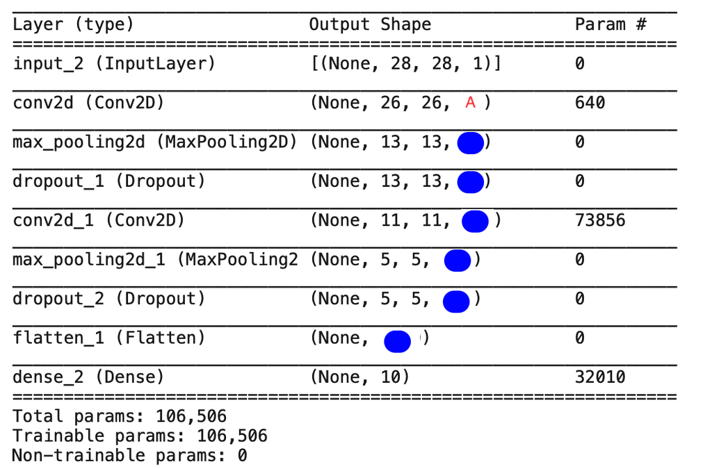

```python
Image('model_ex.png')
```

## tensorflow 불러오기

`import tensorflow as tf`를 사용하여 tensorflow를 tf로 사용합니다.(파이썬 문법)  
우리는 tensorflow 중에서 **keras**를 사용하여 모델을 만ㄷ르어 보겠습니다.

```python
import tensorflow as tf
from tensorflow.keras import Input, Model
from tensorflow.keras.layers import *
```

### 다음은 python을 사용하는데 필요한 라이브러리를 호출합니다.

```python
import numpy as np
import matplotlib.pyplot as plt
import matplotlib.image as mpimg
```

### MNIST는 사람의 손글씨를 모아 놓은 데이터 입니다.

```python
Image('MNIST.png')
```

[output not shown]

훈련 데이터 6만개, 테스트 데이터 1만개로 구성되어 있으며 tensorflow의 내장 함수를 사용하여 쉽게 불러올 수 있습니다.  
각 데이터는 2차원의 이미지 형태 이며, 가로 28픽셀 세로 28픽셀로 28x28데이터 입니다.  
각 데이터 포인트는 0~255사이 값을 가지고 있습니다

```python
mnist = tf.keras.datasets.mnist
```

```python
(x_train, y_train), (x_test, y_test) = mnist.load_data()
x_train, x_test = x_train / 255.0, x_test / 255.0
```

```
Downloading data from https://storage.googleapis.com/tensorflow/tf-keras-datasets/mnist.npz
```

Deep learning을 할 때 데이터가 0~1 사이의 값을 가지는 것이 학습이 잘됩니다.  
따라서 학습 데이터를 최대값 255로 나누어서 0~1 사이 값을 가지도록 만듭니다.

## CNN을 사용하여 모델을 만들어 보겠습니다.

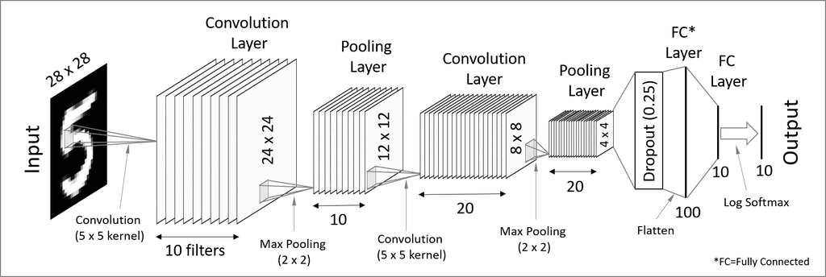

```python
Image('network.png')
```

CNN 모델은 2차원 데이터는 2차원 형태로 분석하고자 하는 것입니다.  
과거 이미지 처리에서 사용한 mask를 사용하여 이미지를 분석하던 것과 비슷한 방법입니다.

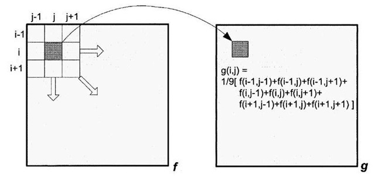

```python
Image('image_processing_mask.jpg')
```

CNN은 이 mask를 deep learning을 사용하여 학습해 보는 것입니다.

### 데이터 변환

먼저 CNN을 사용하기 위해서는 3차원 데이터 형태로 만들어야 합니다.  
2차원으로 각 데이터의 위치를 지정해주고 데이터의 값 차원을 추가해서 총 3차원으로 만듭니다.

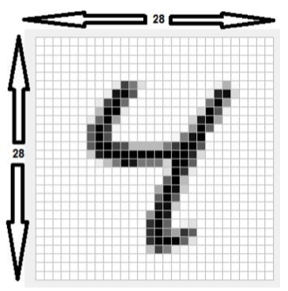

```python
Image('99DE9B3D5AD70ABB05.png')
```

```python
train_img = x_train.reshape((-1,28,28,1))
test_img = x_test.reshape((-1,28,28,1))
```

### CNN 모델을 만듭니다.

**CNN layer + MaxPooling layer + Dropout layer**를 1개의 셋트로 총 2개 만들고  
최종 결과를 출력하기 위해서 Flatten layer와 Dense layer를 통해 판별합니다.

activation의 종류에는 ReLU, Sigmoid, Softmax, Softplus, Softsign...등이 있음

ReLU(Rectified Linear Unit,정류된 선형 유닛 함수 기반)  
-> 입력값이 0보다 작으면 0으로 출력, 0보다 크면 입력값 그대로 출력하는 유닛이다.

2015245'82' 이므로 Conv2d 필터를 64가 아닌 82겹으로 설정

2x2 size의 Max Pooling 2D Matrix -> 차원을 절반으로 줄임.

첫 번째 dropout은 0.4 그대로

이전 단계 필터 수의 2배인 164개의 3x3 matrix filters

두 번째 dropout은 0.3 으로 조정

dropout했을 때의 차원과 filter 개수를 곱해서 1차원으로 쭉 늘임

Dense과정에서 10개의 해답(0~9)를 출력하게 하고 activation을 softmax로 함으로써 결과를 확률로 보여준다.

**Softmax** converts a real vector to a vector of categorical probabilities.

-> 결과의 합을 1로 만들어 줌으로써 결과에 확률론적 의미를 부여하는 역할을 한다.

```python
CNN_input = Input(shape = (28,28,1))
CNN = Conv2D(82,(3,3),activation='relu')(CNN_input) #82개의 3x3 matrix filters
CNN = MaxPool2D((2,2))(CNN) #2x2 size의 Max Pooling 2D Matrix
CNN = Dropout(0.4)(CNN) #0.4%의 확률로 dropout
CNN = Conv2D(164,(3,3),activation='relu')(CNN) # 전 단계 필터 수의 2배인 164개의 3x3 matrix filters
CNN = MaxPool2D((2,2))(CNN) #2x2 size의 Max Pooling 2D Matrix
CNN = Dropout(0.3)(CNN) #0.3%의 확률로 dropout
CNN = Flatten()(CNN) #dropout했을 때의 차원과 filter 개수를 곱해서 쭉 늘임
CNN = Dense(10,activation='softmax')(CNN)
CNN_model = Model(CNN_input,CNN)
CNN_model.summary()
```

```
Model: "model"
_________________________________________________________________
Layer (type)                 Output Shape              Param #
=================================================================
input_1 (InputLayer)         [(None, 28, 28, 1)]       0
_________________________________________________________________
conv2d (Conv2D)              (None, 26, 26, 82)        820
_________________________________________________________________
max_pooling2d (MaxPooling2D) (None, 13, 13, 82)        0
_________________________________________________________________
dropout (Dropout)            (None, 13, 13, 82)        0
_________________________________________________________________
conv2d_1 (Conv2D)            (None, 11, 11, 164)       121196
_________________________________________________________________
max_pooling2d_1 (MaxPooling2 (None, 5, 5, 164)         0
_________________________________________________________________
dropout_1 (Dropout)          (None, 5, 5, 164)         0
_________________________________________________________________
flatten (Flatten)            (None, 4100)              0
_________________________________________________________________
dense (Dense)                (None, 10)                41010
=================================================================
Total params: 163,026
Trainable params: 163,026
Non-trainable params: 0
_________________________________________________________________
```

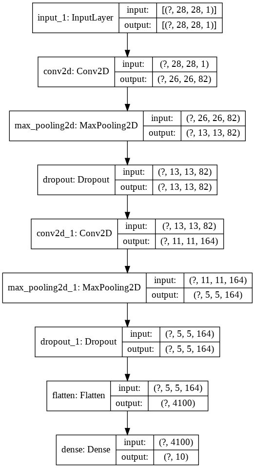

```python
tf.keras.utils.plot_model(CNN_model, show_shapes=True)
```

#### 동일하게 컴파일 해주고 학습을 시작합니다.

많이 느립니다.

google colab에서 1875로 나오는 이유는 modle.fit의 기본 parameter의 batch_size가 32로 설정되어있다.  
이는 mnist의 training data의 개수가 60000개에서 32(batch_size)를 나누면 1875가 된다.  
다시 말해 60000개의 데이터를 한번에 32개씩 모아서 총 1875개의 batch를 5번의 epoch를 통해 학습이 진행된다.  
이렇게 하는 이유는 32개의 데이터를 1개의 batch로 학습을 진행하게 되면 60000개를 1개씩 진행하는 것 보다 Colab환경에서는 빠르게 진행하기 때문이다.

```python
CNN_model.compile(optimizer='adam',
              loss='sparse_categorical_crossentropy',
              metrics=['accuracy'])
#CNN_model.fit(train_img,y_train,batch_size=1 ,epochs=5) #training 소요시간: 5분 6초 5밀리초
CNN_model.fit(train_img,y_train,epochs=5) #-> 기본으로 batch_size = 32로 세팅 #training 소요시간: 2분 53초 92밀리초 -> 1/2
```

```
<tensorflow.python.keras.callbacks.History at 0x7f70bf98b1d0>
```

```python
CNN_model.evaluate(test_img,  y_test,verbose=2) #7 sec 99%
#CNN_model.evaluate(test_img,  y_test, batch_size=1,verbose=2) #22 sec 99%
```

```
313/313 - 7s - loss: 0.0275 - accuracy: 0.9913
```

```
[0.02746201492846012, 0.9912999868392944]
```

### 위의 모델은 정확도가 99%가 나온것을 알 수있었다.

google Colab을 사용하면서 이 mnist모델에 대해 알 수 있었던 사실은  
model의 fit(training)과정에서 batch_size를 조절하여 여러개의 데이터를 한번에 학습하면  
메모리 사용량을 늘어나지만 작업 진행 속도가 빨라진다는 사실을 알 수 있었다.  
마찬가지로 evaluate과정 역시 batch_size를 조절하여 여러개의 데이터를 한번에 측정하면 속도에 차이가 난다는 사실을 알 수있었다.  
**위 사실들**을 통해 데이터를 학습하고 모델 성능 측정할 때 batch_size를 적절하게 설정한다면  
더 빠르고 효율적으로 진행할 수 있다는 것을 알 수 있었다.